# Descriptive overview of LLM extractions: run 0612

Zhongtian Sun, Maxwell J. Farrell, Liam Brierley

June 16 2025

#### Check all 100 docs are present in each file:

```
## [1] 100
```

```
## [1] 100
```

```
## [1] 100
```

```
## [1] 100
```

```
## [1] 100
```

```
## [1] 100
```

```
## [1] 100
```

```
## [1] 100
```

#### Are there duplicated rows in any model outputs?

*Should be zero.*

|  | Duplicated entitity rows | Duplicated relation rows |
| --- | --- | --- |
| deepseek | 0 | 0 |
| gemma2 | 0 | 0 |
| llama | 0 | 0 |
| llama70b | 0 | 0 |
| mistral | 0 | 0 |

### Average entities/relations per doc

__

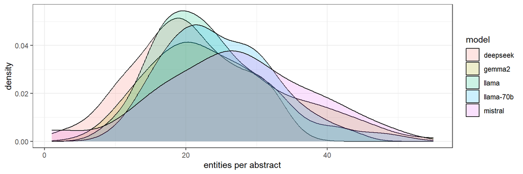

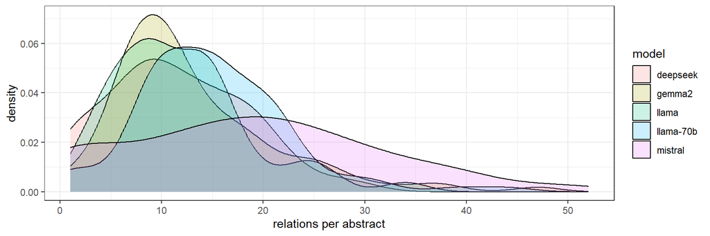

### Most common types of entities

**Note only plotted if a given threshold PER MODEL**

__

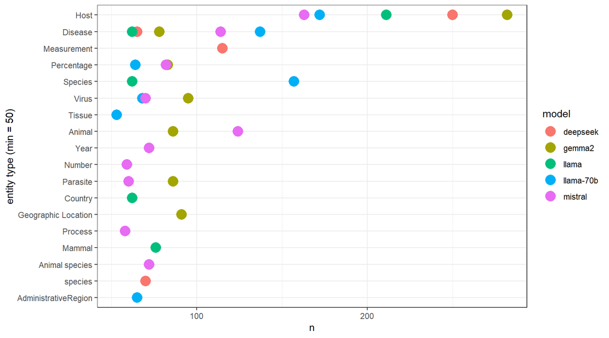

```r
ent_m %>% filter(type == "Unknown") %>% slice(1:25)
```

```
## [1] entity_id entity    type      doc_id
## <0 rows> (or 0-length row.names)
```

```r
ent_d %>% filter(type == "Undefined") %>% slice(1:25)
```

```
## [1] entity_id entity    type      doc_id
## <0 rows> (or 0-length row.names)
```

### Compare entity types for same entity texts WITHIN models

| model | 1 | 2 | 3 | 4 | 5 | 6 | 7 |
| --- | --- | --- | --- | --- | --- | --- | --- |
| deepseek | 93.0 | 5.3 | 1.2 | 0.3 | 0.1 | 0.1 | 0.1 |
| gemma2 | 92.8 | 5.3 | 1.4 | 0.4 | 0.1 | NA | NA |
| llama | 93.7 | 5.3 | 0.7 | 0.2 | NA | NA | NA |
| llama70b | 94.8 | 4.4 | 0.6 | 0.2 | 0.0 | NA | NA |
| mistral | 93.6 | 5.2 | 0.9 | 0.3 | NA | NA | NA |

*Example entities with >1 type within model:*

```r
ent_l %>% filter(entity %in% (ent_l %>% group_by(entity) %>% summarise(nt = n_distinct(type)) %>% filter(nt>1) %>% pull(entity))) %>% arrange(desc(entity)) %>% select(-entity_id, -doc_id) %>% distinct %>% slice(1:20)
```

```
##                     entity                           type
## 1  western lowland gorilla        Gorilla gorilla gorilla
## 2  western lowland gorilla              Mammal subspecies
## 3                      two             Number of isolates
## 4                      two                         Number
## 5                  tissues          Anatomical structures
## 6                  tissues              Anatomical tissue
## 7                    ticks                      Arachnida
## 8                    ticks                       Arachnid
## 9                    three         Number of harbor seals
## 10                   three                         Number
## 11            surveillance           Disease surveillance
## 12            surveillance                        Process
## 13                     sex      Biological characteristic
## 14                     sex            Host characteristic
## 15                     sex                 Biological Sex
## 16                   serum               Biological fluid
## 17                   serum              Biological sample
## 18          seroprevalence                    Measurement
## 19          seroprevalence         Biostatistical measure
## 20               schizonts Plasmodium developmental stage
```

### Compare entity types for same entity texts BETWEEN models

*ONLY for entities having a single type within models (i.e., 1’s in table above). Rows are n models the entity was present in, columns are n types the entity had between models. The ideal is x = 5, y = 1, i.e., the entity was extracted by all five models and all models agreed on the entity type*

|  | 1 | 2 | 3 | 4 | 5 |
| --- | --- | --- | --- | --- | --- |
| 5 | 87 | 113 | 144 | 127 | 122 |
| 4 | 68 | 86 | 158 | 165 | 0 |
| 3 | 100 | 152 | 283 | 0 | 0 |
| 2 | 180 | 601 | 0 | 0 | 0 |
| 1 | 1657 | 0 | 0 | 0 | 0 |

*Example entity with varying and non-varying types between models. Full entity-by-entity sheet is in file *model_entity_type_comparison.csv**

```r
ent_type_comp %>% filter(models_present == 5 & n_entity_types == 1) %>% sample_n(1)
```

```
## # A tibble: 1 × 8
##   entity deepseek   gemma2     llama      llama70b mistral
##   <chr>  <chr>      <chr>      <chr>      <chr>    <chr>
## 1 42%    Percentage Percentage Percentage Percent… Percen…
## # ℹ 2 more variables: models_present <dbl>,
## #   n_entity_types <int>
```

```r
ent_type_comp %>% filter(models_present == 5 & n_entity_types == 5) %>% sample_n(1)
```

```
## # A tibble: 1 × 8
##   entity       deepseek gemma2  llama     llama70b mistral
##   <chr>        <chr>    <chr>   <chr>     <chr>    <chr>
## 1 Taenia parva species  Cestode Species … Species… Parasi…
## # ℹ 2 more variables: models_present <dbl>,
## #   n_entity_types <int>
```

### Most common types of relations

__

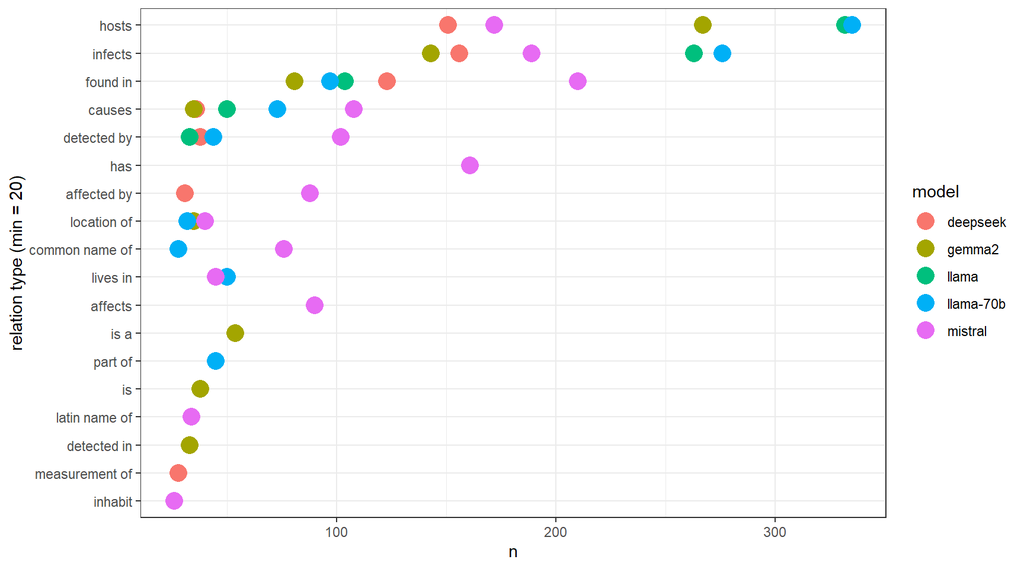

### Examine Latin name of/common name of relations

*ALL MODELS have directional errors in common/latin name of, e.g.:. This is probably then easiest to harmonise with RAG or external referencing or even embedding idea*

```r
rel_ll %>% filter(relation_type == "common name of") %>% slice(1:10)
```

```
##               source_text                target_text
## 1        southern chamois        Rupicapra pyrenaica
## 2              black bear           Ursus americanus
## 3          lone star tick    Amblyomma americanum L.
## 4     American alligators Alligator mississippiensis
## 5            Ursus arctos                brown bears
## 6  eastern spotted skunks         Spilogale putorius
## 7            common genet            Genetta genetta
## 8           bighorn sheep            Ovis canadensis
## 9  Andean hog-nosed skunk           Conepatus chinga
## 10          Martes martes                pine marten
##     relation_type doc_id
## 1  common name of  59578
## 2  common name of  59921
## 3  common name of  59859
## 4  common name of  57753
## 5  common name of  57730
## 6  common name of  60365
## 7  common name of  60214
## 8  common name of  60291
## 9  common name of  60201
## 10 common name of  60486
```

### Abstracts missing predefined entity and relation types:

__

|  | Abs with no ‘Host’ entity | Abs with no ‘Pathogen’ entity | Abs with no ‘hosts’ relation | Abs with no ‘infects’ relation | Abs with neither relation |
| --- | --- | --- | --- | --- | --- |
| deepseek | 52 | 96 | 38 | 36 | 35 |
| gemma2 | 50 | 93 | 22 | 40 | 20 |
| llama | 57 | 100 | 4 | 8 | 2 |
| llama70b | 65 | 98 | 5 | 9 | 5 |
| mistral | 62 | 97 | 32 | 34 | 29 |

__

__

### Find any relations whose source or target entity do not appear in the matching entities file

*Should be zero for all*

|  | Abs with ‘Source’ not in entities | Abs with ‘Target’ not in entities |
| --- | --- | --- |
| deepseek | 0 | 0 |
| gemma2 | 0 | 0 |
| llama | 0 | 0 |
| llama70b | 0 | 1 |
| mistral | 0 | 0 |